# Sociabilidad

Juan Rivera

23 marzo 2021

# Progresos del R Markdown

# Introducción a este R-Markdown

En el presente documento se intenta graficar mediante la base de datos PNUD2012 las preguntas relacionadas con el tema de la sociabilidad en Chile.

Arriba de cada chunk se puede ocultar o mostrar el código correspondiente a cada gráfica de los sets de preguntas seleccionados.

La codificación completa se encuentra en el R Markdown que sirve para construir este documento html.

El presente documento será actualizado a medida que se vaya avanzando en el análisis de los datos y se vayan haciendo las inferencias pertinentes.

# Conjunto de preguntas 96

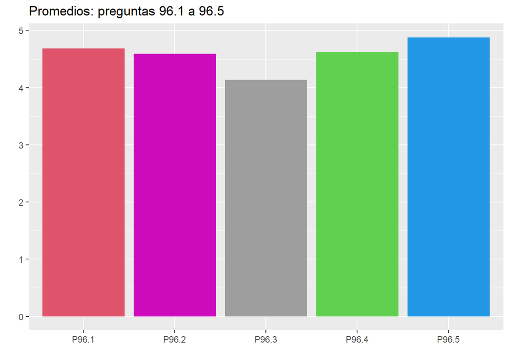

```r
# Pregunta 96

ggplot()+
  geom_bar(P96M, mapping = aes(Pregunta, Valor), stat = "identity",
           fill =c(2,6,8,11,20))+
  ggtitle("Promedios: preguntas 96.1 a 96.5")+
  xlab("")+
  ylab("")
```

# Conjunto de preguntas 117

“¿Con qué frecuencia realiza usted las siguientes actividades con su familia? (conversar sobre asuntos familiares)” - 1) Nunca; 2) Solo en algunas ocasiones; 3) Con cierta frecuencia; 4) Habitualmente

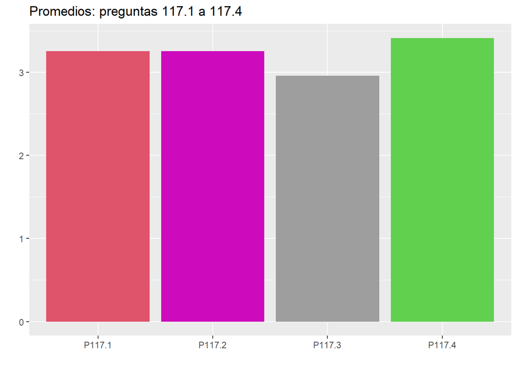

```r
# Preguntas 117

ggplot()+
  geom_bar(P117M, mapping = aes(Pregunta, Valor), stat = "identity",
           fill =c(2,6,8,11))+
  ggtitle("Promedios: preguntas 117.1 a 117.4")+
  xlab("")+
  ylab("")
```

# Pregunta 118

“En el último mes, ¿cuántas veces ha sido invitado/a a la casa de amigos o invitado/a a salir?” Respuestas: 1) Nunca; 2) Sólo una vez; 3) 2 o 3 veces al mes; 4) Más de una vez por semana

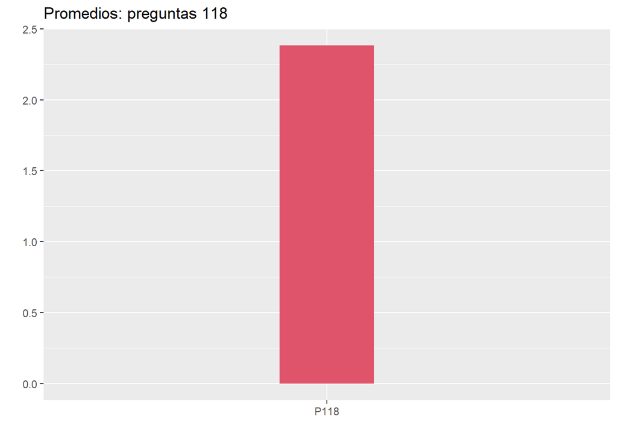

```r
ggplot()+
  geom_bar(P118M, mapping = aes(Pregunta, Valor), stat = "identity",
           fill =c(2), width = 0.2)+
  ggtitle("Promedios: preguntas 118")+
  xlab("")+
  ylab("")
```

# Pregunta 119

"Con respecto al tema de la amistad, ¿usted diría que…? 1) Tiene muchos amigos; 2) Tiene pocos amigos; 3) No tiene amigos, solo conocidos

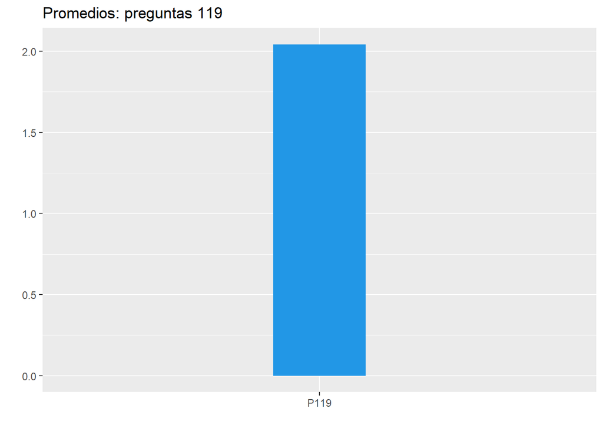

```r
ggplot()+
  geom_bar(P119M, mapping = aes(Pregunta, Valor), stat = "identity",
           fill =c(4), width = 0.2)+
  ggtitle("Promedios: preguntas 119")+
  xlab("")+
  ylab("")
```

# Conjunto de preguntas 121

121.1: “Cuán de acuerdo se encuentra con las siguientes afirmaciones? (Me siento una persona muy querida y valorada)” 1) Muy en desacuerdo; 2) En desacuerdo; 3) De acuerdo; 4) Muy de acuerdo 121.2: “Cuán de acuerdo se encuentra con las siguientes afirmaciones? (Frecuentemente me siento solo/a) 121.3:”Cuán de acuerdo se encuentra con las siguientes afirmaciones? (La gente que me rodea se preocupa mucho por mi)

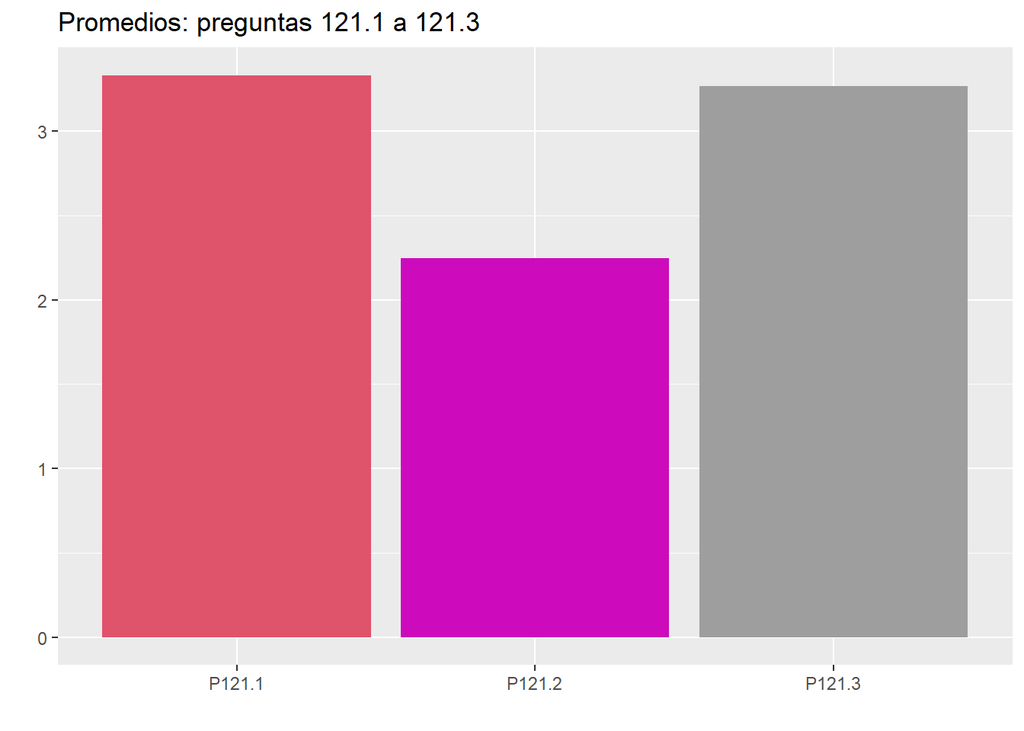

```r
# Preguntas 121

ggplot()+
  geom_bar(P121M, mapping = aes(Pregunta, Valor), stat = "identity",
           fill =c(2,6,8))+
  ggtitle("Promedios: preguntas 121.1 a 121.3")+
  xlab("")+
  ylab("")
```